# Statistical Uncertainty in the Ranking of Journals and Universities

ECON 687 — University of Maryland

## The Paper

## What Question Does It Ask?

Rankings of journals and universities drive real decisions in hiring, promotion, and funding. They are almost always reported as a single number with no indication of how precisely that rank is estimated.

This paper asks: **given that impact factors are themselves estimated with uncertainty, how much uncertainty surrounds the resulting ranks?**

The authors construct confidence sets for ranks. Rather than saying a journal is ranked 5th, they report the full range of ranks that cannot be statistically rejected at the 95% level.

## Method in Plain Terms

An impact factor is an average computed from a finite number of articles. It carries a standard error. When you rank things by noisy estimates, the ranks themselves are noisy.

The pipeline:

1. Start with point estimates (impact factors) and their standard errors
2. Build a covariance matrix capturing estimation uncertainty
3. Run a bootstrap simulation to generate possible rankings under that uncertainty
4. Report, for each journal or university, the set of ranks consistent with the data

The method is implemented in `csranks`, an R package written by the authors.

## What Did They Find?

**Universities** — 100 universities ranked by average publication impact factor:

- Rankings at the very top and bottom are fairly precise
- Substantial uncertainty throughout the middle of the distribution

The main takeaway: point rankings overstate what the data can actually tell us.

## The Data

## Journal Data — What the Raw Excel Looks Like

One sheet per journal, one row per article. Columns are years of citations received.

```
| Avg/yr | ... | 2006 | 2007 | 2008 | 2009 | 2010 | 2011 |
|--------|-----|------|------|------|------|------|------|
| 4.14   | ... | 2    | 1    | 8    | 3    | 7    | 6    |
| 9.57   | ... | 8    | 8    | 8    | 10   | 18   | 12   |
| 2.57   | ... | 0    | 4    | 6    | 3    | 1    | 3    |
| 14.71  | ... | 0    | 3    | 12   | 23   | 24   | 31   |
```

The impact factor is the average citations received in 2011 per article. `convertdata.R` loops through all 233 sheets and computes mean and SE for each.

## Journal Data — convertdata.R

```r
for (s in sheetnames[-1]) {
  X <- as.data.frame(mylist[s])             # load one journal's sheet
  X <- X[-((nrow(X)-3):nrow(X)),]           # drop the summary rows at the bottom
  col2011 <- names(X)[lastcharscn==".2011"] # find the 2011 column by name

  journalIF <- rbind(journalIF,             # stack results row by row
    c(mean(X[, col2011]),                   # impact factor = mean citations in 2011
      sd(X[, col2011]) / sqrt(nrow(X)),     # SE = sd / sqrt(n articles)
      sd(X[, col2011]),                     # sigma = standard deviation
      nrow(X)))                             # n = number of articles
}
```

## Journal Data — Filtering to the KMS 30

The paper focuses on 30 journals pre-selected by Kalaitzidakis, Mamuneas & Stengos (2003), an earlier study identifying leading outlets in economics. We filter the 232-journal dataset to exactly those 30 by name.

```r
load(file.path("data", "journal IF", "IFdata.RData"))

top30names <- c("JEL", "QJE", "JEP", "JFE", "JPE", "Econometrica",
                "AER", "REStud", "RESTAT", "JLE", "JEEM", "JHumRes",
                "J INT ECON", "EconJ", "JMonEcon", "JEconometrics",
                "RAND J ECON", "J BUS ECON STAT", "JPubEcon",
                "JAppliedEconmet", "EUR ECON REV", "IER", "JET",
                "OXFORD B ECON STAT", "GAME ECON BEHAV",
                "J ECON DYN CONTROL", "SCAND J ECON",
                "ECONOMET THEOR", "Econ Theory", "EL")

jIF <- journalIF %>%
  filter(!is.na(IF), IF > 0, journal %in% top30names) %>%
  arrange(desc(IF)) %>%
  mutate(rank = row_number())

cat("Journals matched:", nrow(jIF), "of 30")
```

```
## Journals matched: 30 of 30
```

## Journal Data — Usable form

Top 10 journals by 2011 impact factor

| Rank | Journal | IF | SE | N_articles |
| --- | --- | --- | --- | --- |
| 1 | JEL | 9.281 | 1.387 | 96 |
| 2 | QJE | 8.261 | 0.573 | 207 |
| 3 | JEP | 6.027 | 0.596 | 221 |
| 4 | JFE | 5.730 | 0.344 | 477 |
| 5 | JPE | 5.050 | 0.439 | 159 |
| 6 | Econometrica | 4.567 | 0.381 | 277 |
| 7 | AER | 4.135 | 0.182 | 964 |
| 8 | REStud | 4.097 | 0.317 | 237 |
| 9 | RESTAT | 3.764 | 0.307 | 313 |
| 10 | JLE | 3.316 | 0.498 | 117 |

## RePEC Data — What the Raw File Looks Like

One row per author per publication type. The affiliation field encodes institution code and weight. Columns are article-level impact factors or citation counts.

```
affiliation                             author  type  X1      X2      X3
RePEc:edi:aabasch+1                     1       IF    8.8677  9.5333  1.7667
RePEc:edi:aabasch+1                     1       CT    17      1       1
RePEc:edi:aabasch+*RePEc:edi:faphijo+*  2       IF    0.3513  0.9251  0.3513
```

- `+1` = full weight assigned to this institution
- `+*` = weight unspecified, author has multiple affiliations
- Each author has two rows — one IF row and one CT row

`cleandata.R` parses the affiliation strings, computes weighted averages per institution, aggregates across all authors, and removes non-universities. `keeptop100.R` filters to the top 100 and saves `top100unis.csv`.

## University Data — Loading and Wrangling

The university data required less wrangling than the journal data. By the time we load `top100unis.csv` the authors’ cleaning scripts have already computed average impact factors and standard errors per university.

```r
unis <- read.csv(file.path("data", "Repec", "top100unis.csv")) %>%
  filter(!is.na(IFmean)) %>%       # remove any missing values
  arrange(desc(IFmean)) %>%         # sort highest impact factor first
  mutate(rank = row_number())       # assign point ranks 1 through 100

# IFmean = average IF of publications by authors affiliated with that university
# IFse   = standard error of that average
# n      = number of affiliated authors in RePEC

cat("Universities:", nrow(unis), "| Total authors:", sum(unis$n))
```

```
## Universities: 100 | Total authors: 247804
```

## University Data — Usable form

Top 10 universities by average impact factor

| Rank | University | IFmean | IFse | N_authors |
| --- | --- | --- | --- | --- |
| 1 | Chicago | 27.400 | 0.383 | 4237 |
| 2 | Northwestern | 25.674 | 0.521 | 2010 |
| 3 | UCLA | 25.127 | 0.564 | 1979 |
| 4 | MIT | 22.859 | 0.372 | 4179 |
| 5 | BC | 22.274 | 0.590 | 1390 |
| 6 | UCSD | 22.208 | 0.588 | 1417 |
| 7 | Stanford | 22.195 | 0.382 | 4271 |
| 8 | Boston U | 21.921 | 0.547 | 1792 |
| 9 | U Penn | 21.456 | 0.418 | 2738 |
| 10 | NYU | 21.352 | 0.378 | 3058 |

## Descriptive Statistics and Methods

## The Core Econometric Problem — Defining “True Rank”

- **The Problem:** We observe estimated impact factors, not the “true” population impact factors.
- Therefore, any ranking is subject to statistical uncertainty.
- **To define a rigorous rank, we must clear a fundamental statistical hurdle:**

\[r_i = 1 + \sum_{j \neq i} \mathbb{I}(\theta_j > \theta_i)\]

| **Parameter \((\theta)\):** | **Indicator \(\mathbb{I}(\cdot)\):** | **The Rank \((r_i)\):** |
| --- | --- | --- |
| The **true**, unobservable quality score of University \(i\) and \(j\). This is the noise-free value we wish we knew. | A binary variable. It returns **1** if \(\theta_j > \theta_i\) (the “better-than” test) and **0** otherwise. | The sum counts how many schools \(j\) are better than \(i\). The “+1” ensures the top school is Rank 1. |

## Journal Data - Summary Statistics

| Statistic | All 231 Journals | KMS Top 30 |
| --- | --- | --- |
| Mean IF | 1.537 | 3.046 |
| Median IF | 1.222 | 2.374 |
| SD of IF | 1.335 | 2.118 |
| Mean SE | NA | 0.276 |
| Min IF | 0.014 | 0.570 |
| Max IF | 9.281 | 9.281 |

**Reading the table**

- **IF** is the 2011 impact factor, the mean citations per 2008 article
- **SE** is the standard error of that mean
- The KMS 30 sample has a higher mean IF than the full set, by construction
- Substantial variance across the metrics, the noise that makes ranks hard to assign

## University Descriptive Statistics

| Statistic | Value |
| --- | --- |
| Mean IFmean | 11.828 |
| Median IFmean | 10.044 |
| SD of IFmean | 5.963 |
| Mean IFse | 0.311 |
| Total authors | 247804.000 |
| Min IFmean | 3.524 |
| Max IFmean | 27.400 |

## The Full Pipeline

```
data/journal IF/convertdata.R     # Excel (233 sheets) -> IFdata.RData
data/journal IF/journalranking.R  # confidence sets -> Figure 1
data/Repec/cleandata.R            # raw RePEC text -> cleaned data
data/Repec/keeptop100.R           # filter to top 100 universities
data/Repec/emp.topunis.R          # confidence sets -> Figure 2
```

The four-step logic repeated for both datasets:

> **Load clean data, filter to sample, run bootstrap, plot results**

## The Deep Dive: Confidence Sets

To define a rigorous rank, we must clear a fundamental statistical hurdle. For any two institutions \(i\) and \(j\), we test if their estimated performance gap is distinct from the statistical noise:

\[Z_{i,j} = \left| \frac{\widehat{\theta}_j - \widehat{\theta}_i}{SE_{i,j}} \right| > cv\]

We face a critical choice in how we set that critical value (\(cv\)):

| Marginal Confidence Sets | Simultaneous Confidence Sets |
| --- | --- |
| **The Choice:** Use the standard critical value (e.g., \(cv \approx 1.96\)). | **The Choice:** Use an adjusted \(cv\) calculated for joint estimation. |
| **Posing:** Answers: *“Does this single university belong in the Top 10?”* | **Posing:** Answers: *“Are all these ranks accurate relative to one another with 95% confidence?”* |
| **Danger:** High “False Discovery Rate” when ranking many institutions at once. | **Required:** Essential for rigorous, full-dataset rank reporting. |

## The Key Statistical Step — csranks

```r
# Step 1: build a covariance matrix from the standard errors
# diag(SE^2) puts variances on the diagonal, zeros off-diagonal
# This assumes estimation errors are independent across journals
Sigma <- diag(jIF$SE^2)

# Step 2: run the bootstrap
CS <- csranks::csranks(
  jIF$IF,           # point estimates
  Sigma = Sigma,    # covariance matrix
  coverage = 0.95,  # 95% confidence level
  stepdown = TRUE,  # iterative procedure, gives tighter sets
  simul    = FALSE, # marginal sets (each journal covered individually)
  R        = 1000,  # bootstrap draws
  seed     = 101    # reproducibility
)

# Step 3: attach bounds to the data frame
jIF$CSL <- CS$L   # lower bound of rank confidence set
jIF$CSU <- CS$U   # upper bound of rank confidence set
```

## The Figures

## From Bootstrap Output to Figure

Once `csranks()` returns the bounds, the figure follows directly. The bounds become the error bar limits in ggplot.

```r
ggplot(jIF, aes(x = rank, y = reorder(journal, rank))) +
  theme_bw() +
  geom_point(size = 2) +             # dot = point rank estimate
  geom_errorbar(                      # bar = confidence set for rank
    aes(xmin = CSL, xmax = CSU),
    width = 0.4
  ) +
  scale_x_continuous(
    name = "Rank",
    limits = c(1, 32),
    breaks = c(1, 5, 10, 15, 20, 25, 30)
  ) +
  ylab(NULL)
```

## Figure 1 — Journal Rankings

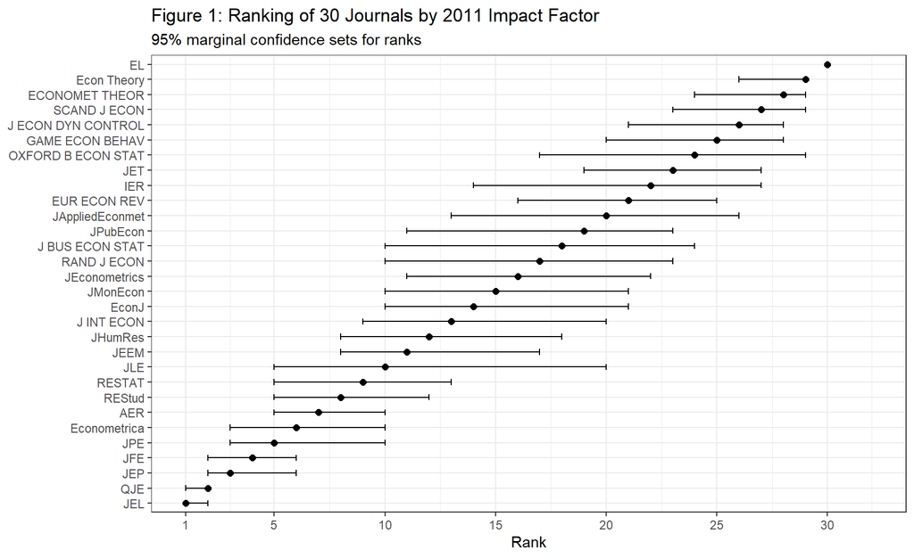

## Figure 1 — Journal Rankings (alt-view)

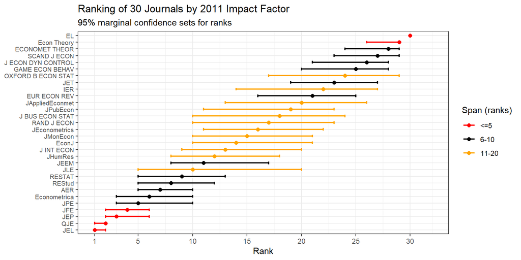

## Figure 2 — University Rankings Code

Same structure as Figure 1 but applied to 100 universities. The csranks bootstrap runs first, then the bounds feed directly into ggplot.

```r
# run bootstrap for university ranks
Sigma_u <- diag(unis$IFse^2)
CS_u <- csranks::csranks(unis$IFmean, Sigma=Sigma_u, coverage=0.95,
                         stepdown=TRUE, simul=FALSE, R=1000, seed=101)
unis$margCSL <- CS_u$L
unis$margCSU <- CS_u$U

# plot - same pattern as Figure 1, scaled to 100 universities
ggplot(unis, aes(x = rank, y = reorder(name, rank))) +
  theme_bw() +
  geom_point(size = 0.7) +
  geom_errorbar(aes(xmin = margCSL, xmax = margCSU), width = 0.4) +
  scale_x_continuous(name = "Rank", limits = c(1,100),
                     breaks = c(1, seq(10,100,by=10))) +
  ylab(NULL) +
  labs(title = "Ranking of 100 Universities by Impact Factor",
       subtitle = "95% marginal confidence sets for ranks") +
  theme(axis.text.y = element_text(size = 5))
```

## Figure 2 — University Rankings

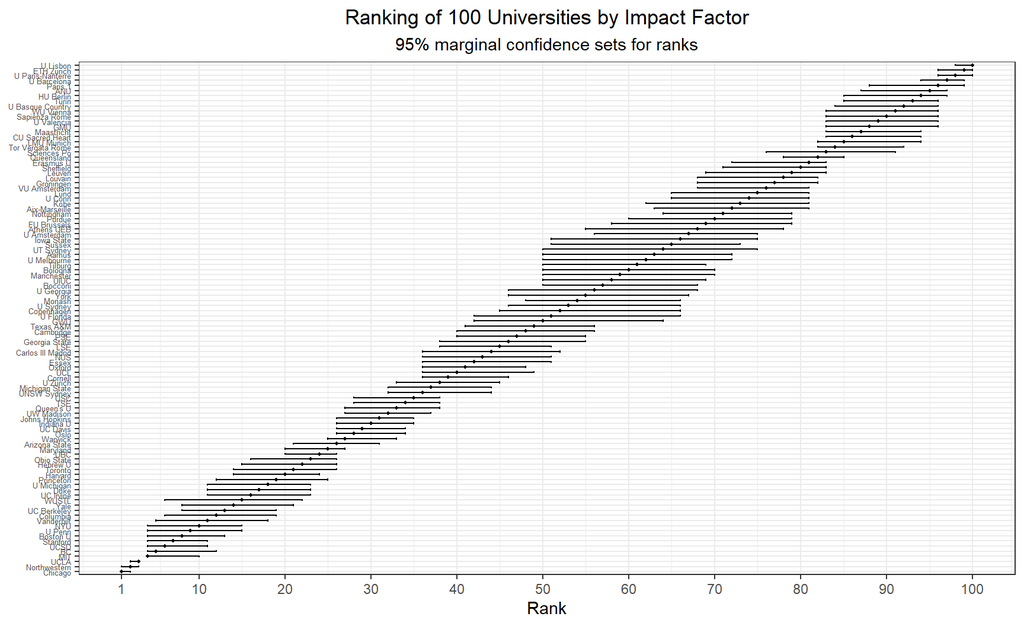

## Figure 2 — University Rankings (alt-view)

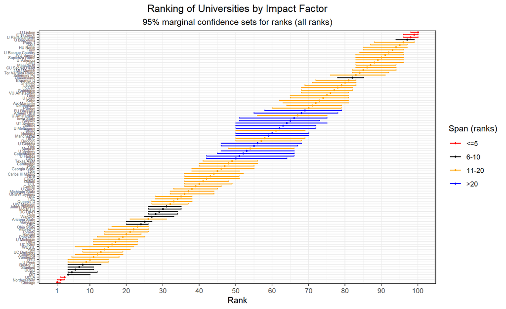

## Figure 2 — University Rankings (alt-view zoomed)

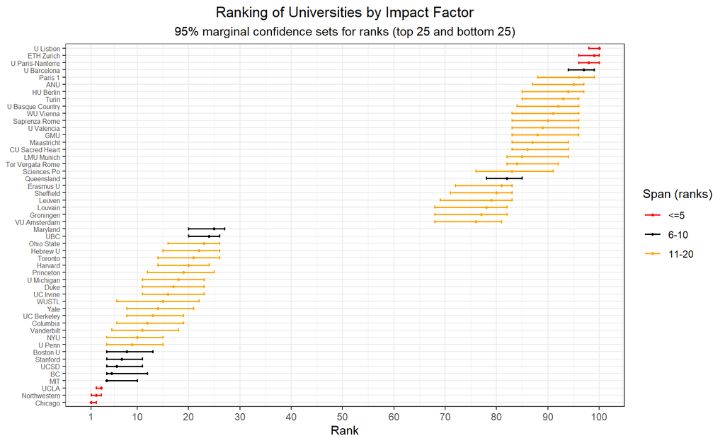

## What the Figures Tell Us

This is the paper’s central point visualized: **point rankings overstate the precision of what we actually know.**

## Replication Notes

## What We Reproduced

Both main figures match the paper exactly. The confidence set bounds were computed using the same `csranks` package the authors wrote, with identical parameters and the same random seed (101) for reproducibility.

One technical issue we worked through: the current version of `csranks` requires a covariance matrix rather than a vector of standard errors. The fix:

```r
# This fails with newer csranks:
csranks(jIF$IF, jIF$SE, ...)

# This works:
csranks(jIF$IF, Sigma = diag(jIF$SE^2), ...)
```

This reflects a deliberate API change by the authors to make the independence assumption explicit rather than assumed silently.